# Cybersecurity Workforce Personality Analysis

Columbus, Georgia

## Introduction

Problem Statement: To understand if highly specialized roles, like cybersecurity, attract workers with similar personality profiles.

Hypothesis to test: Cybersecurity workers are similar in personality to others in the general workforce population.

## Session Aims

- Data Collection and Reporting: Report a personality profile(s) of cybersecurity professionals attending CyberSummit20, in near real-time
- Analysis & Insights: Identify unique personality features (traits) of cybersecurity professionals when compared to the general workforce population
- Conclusions: Share ideas and opinions, non-attributional, through the chat module (so I can benefit from the recording)

## Background (1 of 2)

### Cybersecurity Talent Assessment Design

- Demographic Information (Age, Gender, Years Experience, Education, Certs, Hobbies )
- Personality Assessment (75 Questions, 15 traits)
- *-select individuals-* Cognitive Assessment (6 Questions: Pattern Matching, Matrix, Verbal Reasoning, 3D Shapes)

## Background (2 of 2)

### Personality Assessment

This cybersecurity talent assessment aims to measure 15 underlying personality traits, similar measurements to the [Jackson Personality Inventory - Revised (JPI-R)](https://w8y7a2j5.stackpathcdn.com/wp-content/uploads/2015/03/JPI-R-Scales.pdf).

This JPI-R proxy consists of 75 personality questions that are available through the public domain (https://ipip.ori.org/).

*Personality tests provide a set of measures likely to have implications for a person’s functioning. The measures selectted are most useful for normal populations and appropriate as an aid to vocational counseling.*

## Trait Descriptions (1 of 3)

Analytical

- Complexity: seeks intricate solutions to problems
- Breadth of Interest: interested in learing about a diversity of things
- Innovation: motivated to develop novel solutions to problems; values new ideas
- Tolerance: accepts people even though they may differ from oneself; welcomes dissent

## Trait Descriptions (2 of 3)

Emotional

- Empathy: tends to identify closely with other people and their problems
- Anxiety: tends to worry over inconsequential matters; apprehensive about the future
- Cooperativeness: is susceptible to social influence and group pressures; follows suit

Extroversion

- Sociability: eagerly join a varity of social groups; actively social
- Social Confidence: confident in dealing with others; shows presence in interpersonal situations
- Energy level: is active and spirited; does not tire easily; capable of intense work for long periods

## Trait Descriptions (3 of 3)

Opportunistic

- Social Astuteness: skillful at persuading others to achieve a particlular goal; occasionally seen as manipulative of others, but ordinarily diplomatic
- Risk Taking: enjoys gambling and taking a chance; willingly exposes self to situations with uncertain outcomes

Dependable

- Organization: makes effective use of time; not easily distracted
- Traditional Values: values traditional customs and beliefs; others may view individual as “old-fashioned”
- Responsibility: strong obligation to be honest and upright; strong an inflexibly conscience

## Gender Differences

Do gender differences in personality impact this analysis?

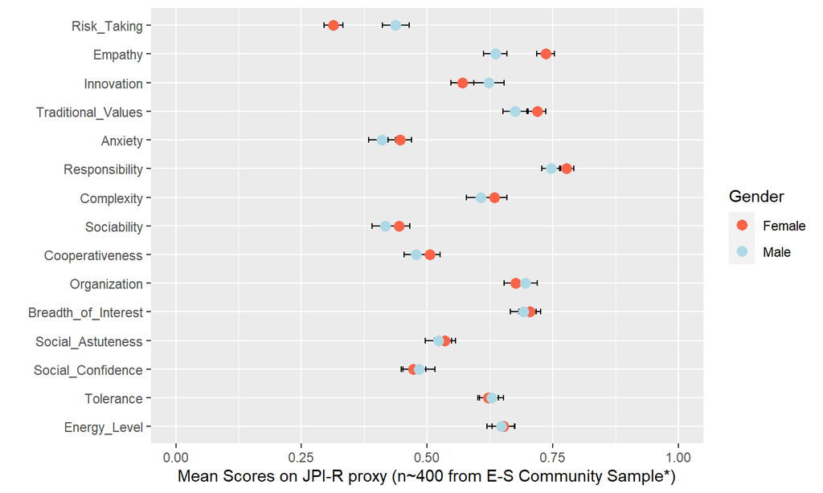

## Highest Level of Education

Cybersecurity professionals: 71% of post-secondary degrees were in computer science or a CS related field.

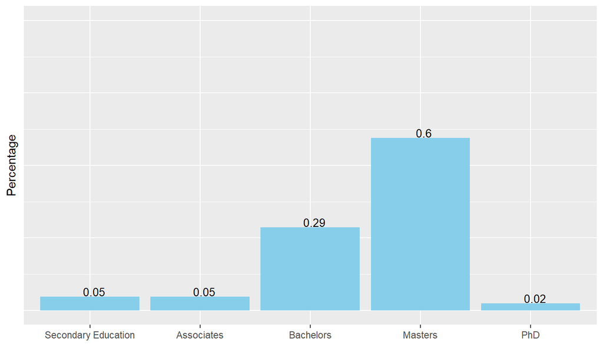

## Age and Years of Experience

Cybersecurity professionals: median age is 48 years old; median years of experience is 6.5 years.

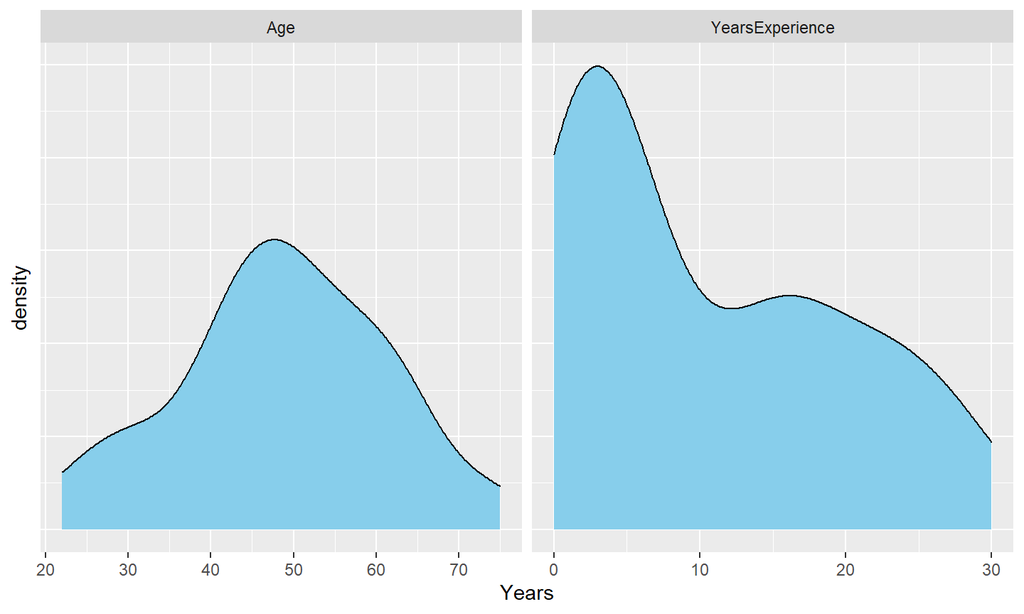

## Personality Results

Group mean is scaled to the general workforce standard normal distribution.

[interactive chart not shown]

## Hierarchical Clustering Analysis

Participant dendrogram developed from item responses. How many clusters should we analyze?

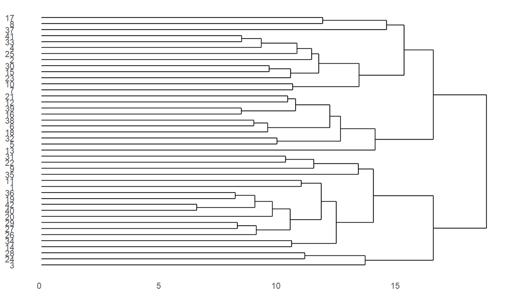

## Latent Profile Analysis

Unsupervised learning based on patterns of responses determines cluster assignment. Cluster summary statistics are displayed.

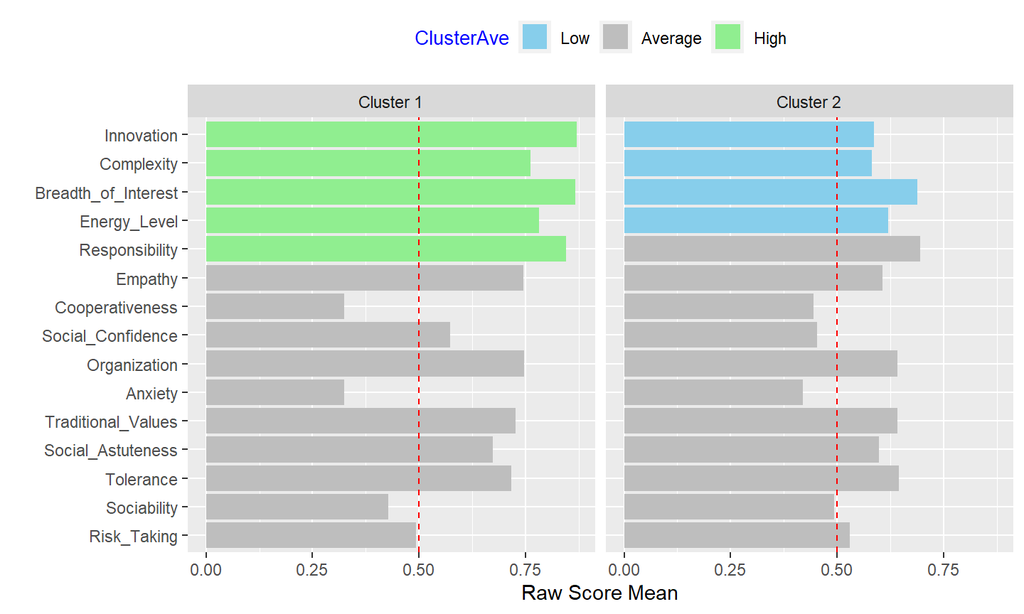

Scores scaled to the general workforce standard normal distribution.

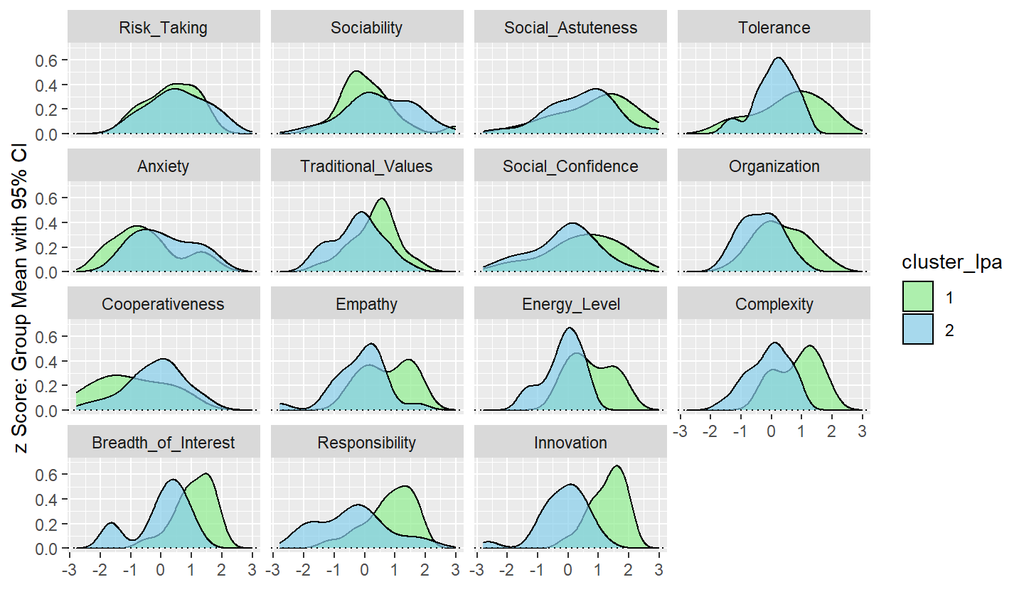

Cluster mean scores with 95% confidence interval around the mean.

[interactive chart not shown]

## Correlation Analysis

Does demographic information predict cluster assignment?

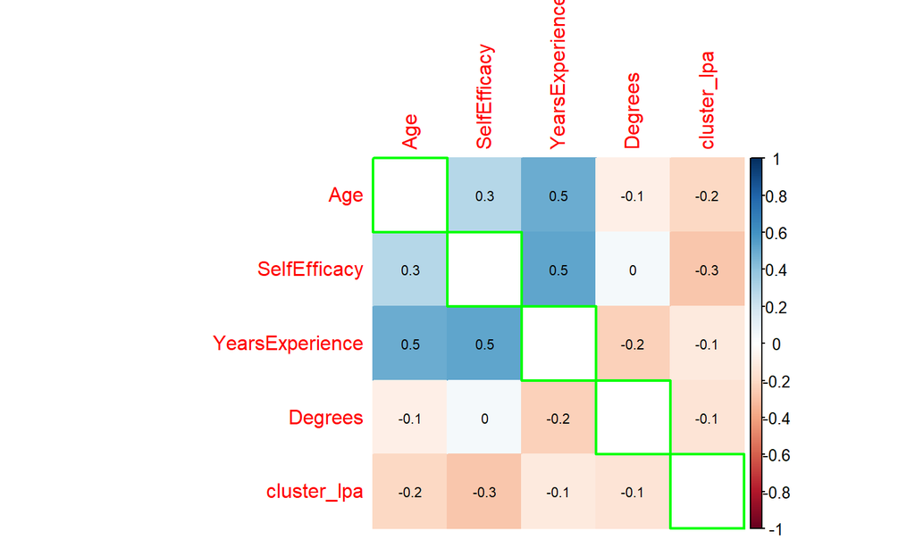

## Conclusions

Review:

Hypothesis to test: Cybersecurity workers are similar in personality to others in the general workforce population.

You decide: *Accept* the Null Hypothesis -or- *Reject* the Null Hypothesis

Does personality predict professional interests and talent to perform specialized work roles?

## Rasch Scoring (eRM package)

This function computes the parameter estimates of a Rasch model for binary item responses by using conditional maximum likelihood estimation (CML).

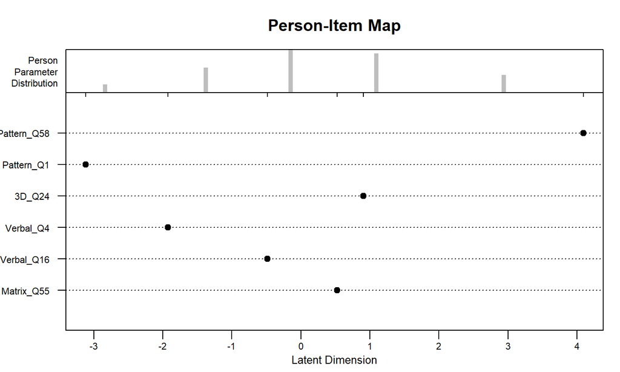

## Rasch Scoring Person Parameters (Theta)

```
##
## Person Parameters:
##
##  Raw Score   Estimate Std.Error
##          0 -4.3461620        NA
##          1 -2.8368256  1.307466
##          2 -1.3785665  1.142064
##          3 -0.1483201  1.089293
##          4  1.0929528  1.174755
##          5  2.9381886  1.580133
```

## References

Douglas N. Jackson, Technical Manual: Jackson Personlaity Inventory - Revised, published by Sigma Assessment Systems, August 1994.

International Personality Item Pool, available at: https://ipip.ori.org/

R Core Team (2019). R: A language and environment for statistical computing. R Foundation for Statistical Computing, Vienna, Austria. URL https://www.R-project.org/.

Eugene-Springfield Community Sample, Harvard Dataverse, available at: https://dataverse.harvard.edu/dataverse/ESCS-Data